# BUSS6002 - Data Science in Business

#### Pre-Tutorial Checklist

1. Complete Task 1 from week 5
2. Complete up to and including Exercise 1

# Tutorial 6 - Linear Algebra and Model Building

# Linear Algebra Review

Linear algebra is the area of maths that deals with vector spaces and linear mappings between those spaces. Vectors are just an ordered list of numbers or variables, so we can represent any data as a vector. Take for instance the table of housing data below:

[figure not shown]

Each row can be represented as a vector in the $ \mathbf a, \mathbf b, \mathbf c $ space spanned by the basis vectors corresponding to the variables Area, Bathrooms and Price:

$$ \mathbf a = [1, 0, 0] $$ $$ \mathbf b = [0, 1, 0] $$ $$ \mathbf c = [0, 0, 1] $$

The 1st row can then be represented as a 3-dimensional vector by taking a weighted sum of the basis vectors:

$$ \mathbf x_1 = 350 \mathbf a + 3 \mathbf b + 1060000 \mathbf c = [350, 3, 1060000] $$

Similarly, each column of data can be represented as a vector in our *sample* space:

$$ \mathbf A = \begin{bmatrix}350\\200\\540\\275\end{bmatrix} $$

There is no reason why we could not represent our table columns as row vectors and our table rows as column vectors, we only need to be consistent in our choices.

Matrices are like vectors with an additional dimension, and can be thought of as a collection of vectors. Conversely, we can also think of vectors as lower-dimensional matrices. We can represent the data in the table above as a $4\times3$ matrix:

$$ \mathbf X = \begin{bmatrix}350 & 3 & 1060000\\200 & 2 & 620000 \\540 & 3 & 1490000\\275 & 3 & 900000\end{bmatrix} $$

We say this matrix is rectangular since 4 ≠ 3. Matrices with an equal number of rows and columns ($m \times m$ matrices), are referred to as *square* matrices. These matrices are especially useful in that they can be invertible. This will be useful when dealing with matrix equations, but for now it's enough to know that square matrices are somewhat nicer to deal with than non-square ones.

Matrices are also commonly used to represent image data. For example, the entries in the below matrix represent the greyscale value of each pixel in the image.

[figure not shown]

## Getting Started with Numpy

The Numpy library contains many useful linear algebra functions, and borrows many function names and concepts from MATLAB.

### Documentation - Numpy

https://docs.scipy.org/doc/numpy/reference/

```python
import numpy as np
```

Creating a vector is straight forward with numpy. To create a vector we can use either:

```python
a = np.array([1, 2, 3])

A = np.matrix([1, 2, 3])
```

We can check the shape of a vector using:

```python
print(a.shape)
print(A.shape)
```

```
(3,)
(1, 3)
```

**Note that the shape of vector a is different from vector A. This is because numpy array dimensions are ambiguous. It can be interpreted as a row or column vector. If you want to exactly specify the shape then use the matrix function instead to create your vector.**

Be careful with arrays! Products of arrays are elementwise, not vector multipliciation!

```python
print(a * a)
```

```
[1 4 9]
```

To perform the vector multiplication $ \mathbf a* \mathbf a^T $ we should use the equivalent dot product:

```python
print(np.dot(a,a))
```

```
14
```

The type of data that a vector (and matrix) can store is fixed to a single type. You cannot mix integers, floats etc in the same vector. Numpy infers the data type from the data used to create the vector.

```python
print(a.dtype)

c = np.array([1.0, 2.0, 3.0])

print(c.dtype)
```

```
int64
float64
```

## Shortcuts

### Evenly Spaced Values Over an Interval

#### Documentation - linspace

https://docs.scipy.org/doc/numpy/reference/generated/numpy.linspace.html

```python
# 11 numbers from 0 to 100, evenly spaced
lin_spaced = np.linspace(0, 100, 11)

print(lin_spaced)
```

```
[  0.  10.  20.  30.  40.  50.  60.  70.  80.  90. 100.]
```

### Evenly Spaced Values by Step Size

#### Documentation - arange

https://docs.scipy.org/doc/numpy/reference/generated/numpy.arange.html

```python
# All numbers from 0 up to (not including) 100 with gaps of 2
aranged = np.arange(0, 100, 2)

print(aranged)
```

```
[ 0  2  4  6  8 10 12 14 16 18 20 22 24 26 28 30 32 34 36 38 40 42 44 46
 48 50 52 54 56 58 60 62 64 66 68 70 72 74 76 78 80 82 84 86 88 90 92 94
 96 98]
```

## Equality of Vectors and Matrices

#### Documentation - allclose

https://docs.scipy.org/doc/numpy/reference/generated/numpy.allclose.html

Checking for vector/array equality is a little trickier than checking for equality of other types. Here is how I suggest you check if two vectors are equal

```python
print(np.array_equal(A, A))
print(np.array_equal(A, A.transpose()))

# You may wish to check equality up to a tolerance
# This is useful since floating points aren't perfect
print(np.allclose(A, A, rtol=1e-05))
```

```
True
False
True
```

## More Linear Algebra

Vectors can be summed together as expected, or linear combinations can be formed.

```python
c = a + a

d = 3*a * 1.5*c
```

Numpy Matrices behave in a similar way to vectors

```python
b = np.array([[1, 4, 7],
              [2, 5, 8],
              [3, 6, 9]])

B = np.matrix([[1, 4, 7],
              [2, 5, 8],
              [3, 6, 9]])

print(B)
```

```
[[1 4 7]
 [2 5 8]
 [3 6 9]]
```

Summation is elementwise:

```python
print(B + B)
```

```
[[ 2  8 14]
 [ 4 10 16]
 [ 6 12 18]]
```

We can multiply a matrix by a scalar:

```python
print(3*B)
```

```
[[ 3 12 21]
 [ 6 15 24]
 [ 9 18 27]]
```

Matrix multiplication $ \mathbf A \mathbf B $ is possible if the number of columns in $\mathbf A$ is equal to the number of rows in $\mathbf B$:

```python
print(A * B)
```

```
[[14 32 50]]
```

We can take the transpose of a matrix or vector using `.transpose()` or `.T`.

```python
print(A*A.transpose())
```

[output not shown]

```python
print(B.T)
```

```
[[1 2 3]
 [4 5 6]
 [7 8 9]]
```

Vectors and matrices of compatible dimensions can also be stacked vertically or horizontally to make new matrices using vstack or hstack:

```python
print(np.vstack((A,A)))
```

```
[[1 2 3]
 [1 2 3]]
```

```python
print(np.hstack((B,B.T)))
```

```
[[1 4 7 1 2 3]
 [2 5 8 4 5 6]
 [3 6 9 7 8 9]]
```

### Exercise 1 - Numpy vectors

Use Numpy to evaluate the vector product:

$$x =\begin{bmatrix}2&4&6\end{bmatrix}\begin{bmatrix}1\\2\\3\end{bmatrix}$$

# Regression

## Label, Features and Training Examples

A **label** is the variable which we are trying to estimate. This could be a house price, weather temperature or even a categorical label like brand of car. Usually we use the letter $y$ to denote the label variable. It is also known as the dependant variable or target variable.

A **feature** is an input variable which we use to estimate a label. We can have one or many features for each label. We use the letter $x$ to denote features. Some examples of features could be the size of a house, the number of bedrooms, distance to a school etc. When we have many features for a label we can write them as a vector $$ \mathbf x = [x_1, x_2, ..., x_p] $$

An **example** (or "training example") is a pairing of label and feature. We use training examples to train a model. In other words, given a set of data features $\mathbf x$ we adjust our model so that we get an accurate proediction for $y$ $$ [x_1, x_2, ..., x_p] \rightarrow y $$

An example of features and target for the house price example might include Square Feet, Bedrooms and Bathrooms as Features and the Price as the label.

[figure not shown]

## Training and Inference

Once we have determined what the target variable and feature variables are our next step is to build and test a model. There are two main stages to this process:

- **Training** refers to the learning process. We give the model training examples and the model corrects itself to model or learn the relationships between the features and label.
- **Inference** is the process of applying our model to new data. You use the trained model to make predictions.

[figure not shown]

## Linear Regression

A regression model means a model that predicts a label that is continuous based on a set of features. House prices and temperatures are examples of continuous variables that can be modeled using regression. Variables like brand of car or blood type are not continuous and can be desribed as discrete.

Generally there are two types of linear regression:

**Simple Linear Regression** $$ y = \beta_0 + \beta_1 x $$

**Multiple Linear Regression** $$ y = \beta_0 + \beta_1 x_1 + \dots + \beta_p x_p$$

A regression model can be uniquely described by the parameters $\beta$. They represent the effect or weight that each feature has on the value of the target. Training a regression model is the process of finding the best parameters to minimise the error between training target and predicted target values.

**Simple** means that we only use one feature in this process, whereas **Multiple** regression means that we use multiple features in the model to explain the target variable.

If we write the $\beta_i$ coefficients and features $x_i$ in vector form:

$$ \mathbf{\beta} = \begin{bmatrix}\beta_0\\\beta_1\\\beta_2\\...\end{bmatrix} \qquad \mathbf x = \begin{bmatrix}1&x_1&x_2&...\end{bmatrix} $$

We can write the equation as:

$$ \mathbf x \beta = y $$

If we expand the $\mathbf x$ vector into a matrix, with each row representing an observation in our dataset, we can write the set of linear equations

$$ \beta_0 + \beta_1 x_{11} + \beta_2 x_{12} ... \beta_p x_{1p}= y_1 $$ $$ \beta_0 + \beta_1 x_{21} + \beta_2 x_{22} ... \beta_p x_{2p}= y_2 $$ $$ \beta_0 + \beta_1 x_{31} + \beta_2 x_{32} ... \beta_p x_{3p}= y_3 $$ $$ ... $$ $$ \beta_0 + \beta_1 x_{n1} + \beta_2 x_{n2} ... \beta_p x_{np}= y_n $$

In compact matrix form:

$$\begin{bmatrix}1&x_{11}&x_{12}&...&x_{1p}\\1&x_{21}&x_{22}&...&x_{2p}\\ & &...\\1&x_{n1}&x_{n2}&...&x_{np}\end{bmatrix} \begin{bmatrix}\beta_0\\\beta_1\\\beta_2\\...\\\beta_p\end{bmatrix} = \begin{bmatrix}y_1\\y_2\\...\\y_n\end{bmatrix} $$

### Exercise 2 - Matrix notation

$\quad$ In the above matrix equation, what is represented by the symbols $n$ and $p$?

## Visualisation

Visualisation of a simple linear regression model:

[figure not shown]

Visualisation of a multiple linear regression model with two features:

[figure not shown]

## Ordinary Least Squares method

If we define the error as the difference between the target and the predicted value: $$ e = y - \beta_0 - \beta_1 x $$

then our objective becomes to minimise the square of the error: $$e^2 = ( y - \beta_0 - \beta_1 x ) ^ 2 $$

for all n training examples:

$$ \min_{\beta_0, \beta_1} \sum_{0}^{n}( y - \beta_0 - \beta_1 x_{i} ) ^ 2 $$

## House Price Example

Let's look at an example using house price data collected in Baton Rouge, Louisiana, US, from mid-2005.

- Price: The price the house sold for
- Square Feet: The size of the house in square feet
- Beds: The number of bedrooms in the house
- Baths: The number of bathrooms in the house
- Age: The age of the house in years
- Pool: Does the house have a pool (yes/no)
- Style: What is the architectural style of the house?
- Fireplace: Does the house have a fireplace (yes/no)
- Waterfront: Is the house on the waterfront (yes/no)
- Days on Market: How many days the house spent on the market before it was ultimately sold

### Framing the Problem

Given the Baton Rouge data we can do many regressions depending on which variable we select as the target or features. However there are two guiding questions you can ask yourself:

- Which variable can you estimate from the others? (what is the dependency order of variables)
- What is your goal?

In this example our goal is to estimate the house price. House price is the most obvious dependent variable. All others have only weak dependency on each other. For example we expect that a bigger house is more expensive. But a more expensive house is not always bigger (due to factors such as location).

**Target**: Price

**Features**: All other variables

```python
import pandas as pd

br = pd.read_excel("BatonRouge.xls")

br.head()
```

|  | Price | SQFT | Bedrooms | Baths | Age | Occupancy | Pool | Style | Fireplace | Waterfront | DOM |
| --- | --- | --- | --- | --- | --- | --- | --- | --- | --- | --- | --- |
| 0 | 66500 | 741 | 1 | 1 | 18 | 1 | 1 | Style1 | 1 | 0 | 6 |
| 1 | 66000 | 741 | 1 | 1 | 18 | 2 | 1 | Style1 | 0 | 0 | 23 |
| 2 | 68500 | 790 | 1 | 1 | 18 | 1 | 0 | Style1 | 1 | 0 | 8 |
| 3 | 102000 | 2783 | 2 | 2 | 18 | 1 | 0 | Style1 | 1 | 0 | 50 |
| 4 | 54000 | 1165 | 2 | 1 | 35 | 2 | 0 | Style1 | 0 | 0 | 190 |

### Categorical variables

For each of the available categories a new variable is created. If the category is satisfied then that column is set to 1. The other columns are set to 0. Usually if there are $k$ categories then there will be $k-1$ dummy variables in a linear regression setting. This is to avoid multicolinearity.

Let's quickly detour to learn about how to convert categorical variables to dummy variables.

Imagine we have a tiny dataset with a single categorical variable.

```python
s = pd.Series(list('abca'))
s
```

```
0    a
1    b
2    c
3    a
dtype: object
```

We can get the dummy variables for this dataset by using the pandas get_dummies function. Notice that we have transformed a single variable into three new variables, one for each category.

```python
pd.get_dummies(s)
```

|  | a | b | c |
| --- | --- | --- | --- |
| 0 | 1 | 0 | 0 |
| 1 | 0 | 1 | 0 |
| 2 | 0 | 0 | 1 |
| 3 | 1 | 0 | 0 |

However we should drop one of the categories to avoid multicolinearity. The get_dummies function has a parameter called drop_first to do this for you

```python
s = pd.get_dummies(s, drop_first=True)
s
```

|  | b | c |
| --- | --- | --- |
| 0 | 0 | 0 |
| 1 | 1 | 0 |
| 2 | 0 | 1 |
| 3 | 0 | 0 |

## Simple Linear Regression

First we will build a simple linear regression model.

We know the dependant variable is price, but which independant variable will best predict the price? To determine this you can use two heuristics:

1. Scatter plotting of each independant variable against the dependant
2. Calculate the linear correlation between independant variable and the dependant

Note that option 2. is somewhat risky. Correlation scores only reflect the linear correlation between variables. If there is a strong non-linear relation then it might be missed.

### Documentation - corr()

https://pandas.pydata.org/pandas-docs/stable/reference/api/pandas.DataFrame.corr.html

```python
all_correlations = br.corr()

all_correlations
```

|  | Price | SQFT | Bedrooms | Baths | Age | Occupancy | Pool | Fireplace | Waterfront | DOM |
| --- | --- | --- | --- | --- | --- | --- | --- | --- | --- | --- |
| Price | 1.000000 | 0.760689 | 0.455189 | 0.645341 | -0.208609 | -0.206716 | 0.202269 | 0.310626 | 0.309940 | 0.078929 |
| SQFT | 0.760689 | 1.000000 | 0.684591 | 0.716111 | -0.138031 | -0.308667 | 0.256155 | 0.374238 | 0.214929 | 0.104335 |
| Bedrooms | 0.455189 | 0.684591 | 1.000000 | 0.578808 | -0.168075 | -0.225346 | 0.137703 | 0.210015 | 0.085691 | 0.089487 |
| Baths | 0.645341 | 0.716111 | 0.578808 | 1.000000 | -0.293107 | -0.284255 | 0.202991 | 0.364095 | 0.222732 | 0.074509 |
| Age | -0.208609 | -0.138031 | -0.168075 | -0.293107 | 1.000000 | -0.011167 | 0.009081 | -0.209634 | -0.165418 | -0.064640 |
| Occupancy | -0.206716 | -0.308667 | -0.225346 | -0.284255 | -0.011167 | 1.000000 | -0.095383 | -0.327940 | -0.048484 | 0.070802 |
| Pool | 0.202269 | 0.256155 | 0.137703 | 0.202991 | 0.009081 | -0.095383 | 1.000000 | 0.107466 | 0.089701 | -0.027832 |
| Fireplace | 0.310626 | 0.374238 | 0.210015 | 0.364095 | -0.209634 | -0.327940 | 0.107466 | 1.000000 | 0.123235 | 0.062615 |
| Waterfront | 0.309940 | 0.214929 | 0.085691 | 0.222732 | -0.165418 | -0.048484 | 0.089701 | 0.123235 | 1.000000 | 0.119755 |
| DOM | 0.078929 | 0.104335 | 0.089487 | 0.074509 | -0.064640 | 0.070802 | -0.027832 | 0.062615 | 0.119755 | 1.000000 |

```python
price_correlations = br.corr()['Price'].abs().sort_values()

price_correlations
```

```
DOM           0.078929
Pool          0.202269
Occupancy     0.206716
Age           0.208609
Waterfront    0.309940
Fireplace     0.310626
Bedrooms      0.455189
Baths         0.645341
SQFT          0.760689
Price         1.000000
Name: Price, dtype: float64
```

It looks like the house area (sqft) has the largest linear correlation with price. Let's confirm this with a quick scatter plot

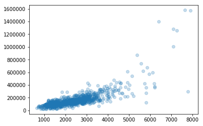

```python
%matplotlib inline
import matplotlib.pyplot as plt

y = br['Price']
x = br['SQFT']

fig = plt.figure()
plt.scatter(x, y, alpha=0.25)
plt.show()
```

Add the intercept term $\beta_0$ to the dataframe

```python
import statsmodels.api as sm

x_with_intercept = sm.add_constant(x, prepend=True)

x_with_intercept.head()
```

|  | const | SQFT |
| --- | --- | --- |
| 0 | 1.0 | 741 |
| 1 | 1.0 | 741 |
| 2 | 1.0 | 790 |
| 3 | 1.0 | 2783 |
| 4 | 1.0 | 1165 |

Fit the model and display the summary of the model. The summary will display the coefficient values ($\beta$) and statistics such as the R-squared and p-value etc.

### Documentation - OLS

http://www.statsmodels.org/dev/generated/statsmodels.regression.linear_model.OLS.html

```python
model = sm.OLS(y, x_with_intercept)

results = model.fit()

print(results.summary())
```

```
                            OLS Regression Results
==============================================================================
Dep. Variable:                  Price   R-squared:                       0.579
Model:                            OLS   Adj. R-squared:                  0.578
Method:                 Least Squares   F-statistic:                     1480.
Date:                Thu, 11 Apr 2019   Prob (F-statistic):          1.54e-204
Time:                        16:24:19   Log-Likelihood:                -13722.
No. Observations:                1080   AIC:                         2.745e+04
Df Residuals:                    1078   BIC:                         2.746e+04
Df Model:                           1
Covariance Type:            nonrobust
==============================================================================
                 coef    std err          t      P>|t|      [0.025      0.975]
------------------------------------------------------------------------------
const      -6.086e+04   6110.187     -9.961      0.000   -7.29e+04   -4.89e+04
SQFT          92.7474      2.411     38.476      0.000      88.018      97.477
==============================================================================
Omnibus:                     1185.147   Durbin-Watson:                   1.886
Prob(Omnibus):                  0.000   Jarque-Bera (JB):           139602.251
Skew:                           5.135   Prob(JB):                         0.00
Kurtosis:                      57.743   Cond. No.                     6.38e+03
==============================================================================

Warnings:
[1] Standard Errors assume that the covariance matrix of the errors is correctly specified.
[2] The condition number is large, 6.38e+03. This might indicate that there are
strong multicollinearity or other numerical problems.
```

### Defining model using a formula

An alternative is to use the statsmodels formula interface to define your model. Statsmodels will pass a string as a formula and select the named columns from the dataframe. One nice feature is that statsmodels will automatically convert categorical variables to dummy variables for you!

```python
import statsmodels.formula.api as smf

formula = "Price ~ SQFT"

model_formula = smf.ols(formula = formula, data = br)

results_formula = model_formula.fit()

# This should be exactly the same as the non-formula method
print(results_formula.summary())
```

```
                            OLS Regression Results
==============================================================================
Dep. Variable:                  Price   R-squared:                       0.579
Model:                            OLS   Adj. R-squared:                  0.578
Method:                 Least Squares   F-statistic:                     1480.
Date:                Thu, 11 Apr 2019   Prob (F-statistic):          1.54e-204
Time:                        16:24:19   Log-Likelihood:                -13722.
No. Observations:                1080   AIC:                         2.745e+04
Df Residuals:                    1078   BIC:                         2.746e+04
Df Model:                           1
Covariance Type:            nonrobust
==============================================================================
                 coef    std err          t      P>|t|      [0.025      0.975]
------------------------------------------------------------------------------
Intercept  -6.086e+04   6110.187     -9.961      0.000   -7.29e+04   -4.89e+04
SQFT          92.7474      2.411     38.476      0.000      88.018      97.477
==============================================================================
Omnibus:                     1185.147   Durbin-Watson:                   1.886
Prob(Omnibus):                  0.000   Jarque-Bera (JB):           139602.251
Skew:                           5.135   Prob(JB):                         0.00
Kurtosis:                      57.743   Cond. No.                     6.38e+03
==============================================================================

Warnings:
[1] Standard Errors assume that the covariance matrix of the errors is correctly specified.
[2] The condition number is large, 6.38e+03. This might indicate that there are
strong multicollinearity or other numerical problems.
```

## Plotting the Regression model

To visualise the regression model we need to input values of $x$ into the equation using the model parameters ($\beta$). The best way to do is to generate values for $x$ evenly spaced along the domain of the independant variable. Then for each value of $x$ calculate the value of the dependant variable.

```python
import numpy as np

min_x = np.min(x)
max_x = np.max(x)

x_points = np.linspace(min_x, max_x, 100)

y_model = results.params[0] + results.params[1] * x_points
```

If you have a multiple regression model it is probably easier to use the statsmodels predict function

```python
x_model = np.array([np.ones(100), x_points])
x_model = x_model.transpose()

y_model = results.predict(x_model)
```

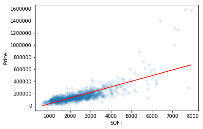

```python
fig = plt.figure()

plt.scatter(x, y, alpha = 0.1)

plt.plot(x_points, y_model, color = "red")

plt.xlabel("SQFT")
plt.ylabel("Price")

plt.show()
```

## Prediction

Prediction means to estimate a value given the model parameters and some new data. For example we might want to estimate the sale price of a house that is about to go on the market.

### Non-Formula

When using the non-formula method you can simply pass in an array/list of values. Don't forget to include the intercept if you used it!

```python
new_house = [1, 1500]

results.predict(new_house)
```

```
array([78259.59937286])
```

### Formula

If you use a formula to build the model you need to use labelled values. The easiest way to do it for a simple case is with a list of dictionaries

```python
new_house_dict = {'SQFT': 1500}

results_formula.predict( new_house_dict )
```

```
0    78259.599373
dtype: float64
```

You can also use a pandas DataFrame to predict multiple values at once!

```python
new_house_df = pd.DataFrame([{'SQFT': 1500}, {'SQFT': 1000}])

print(new_house_df)

results_formula.predict( new_house_df )
```

```
   SQFT
0  1500
1  1000
```

```
0    78259.599373
1    31885.912175
dtype: float64
```

## Evaluating the Model

How can we quantify the ability of our model to reflect the data?

#### Goodness of fit

- RMSE: the Root Mean Square Error measures the total error (distance between the regression line and actual dependant variable value for each training data point, summed over all training data points).
- $R^2$: The R-squared value is a measure of the amount of variance that the model explains. A value of 1 means that the model totally explains all variance. However in most cases this would be considered overfitting.

#### Effect of variables

- p-value: this is the statistical significance of the parameter value being non-zero. This does not mean that the variable should neccesarily be included in the model. You must also check the coefficient value. Often variables should be left in the regression even if their p-value is high so that you can indicate that you have controlled for this variable.
- coefficient value: the magnitude of the coefficient/param value $\beta$. The larger this value the more it contributes to shifting the value of the dependant variable. A large coefficient value means the variable is practically significant. However since variables are at different scale you should standardise your variables first so their scales are the same. Some variables can't be compared in this way e.g. numeric vs categorical.

## Improving the Model

Let's try to improve our model by including all the available features.

```python
x = br.iloc[:, 1:]

x_with_dummies = pd.get_dummies(x)

x_with_dummies_intercept = sm.add_constant(x_with_dummies, prepend=True)
```

```python
model_multivariate = sm.OLS(y, x_with_dummies_intercept)

results_multivariate = model_multivariate.fit()

print(results_multivariate.summary())
```

```
                            OLS Regression Results
==============================================================================
Dep. Variable:                  Price   R-squared:                       0.657
Model:                            OLS   Adj. R-squared:                  0.651
Method:                 Least Squares   F-statistic:                     112.8
Date:                Thu, 11 Apr 2019   Prob (F-statistic):          2.48e-231
Time:                        16:24:19   Log-Likelihood:                -13611.
No. Observations:                1080   AIC:                         2.726e+04
Df Residuals:                    1061   BIC:                         2.736e+04
Df Model:                          18
Covariance Type:            nonrobust
=================================================================================
                    coef    std err          t      P>|t|      [0.025      0.975]
---------------------------------------------------------------------------------
const         -3.192e+04   1.46e+04     -2.186      0.029   -6.06e+04   -3272.027
SQFT             82.8992      3.831     21.637      0.000      75.381      90.417
Bedrooms      -1.873e+04   4769.433     -3.927      0.000   -2.81e+04   -9371.357
Baths          3.889e+04   5575.851      6.975      0.000     2.8e+04    4.98e+04
Age            -354.8098    154.275     -2.300      0.022    -657.529     -52.090
Occupancy      2128.1413   4310.866      0.494      0.622   -6330.651    1.06e+04
Pool          -2583.6976   8794.413     -0.294      0.769   -1.98e+04    1.47e+04
Fireplace     -4228.4564   5188.555     -0.815      0.415   -1.44e+04    5952.538
Waterfront      5.57e+04   9103.956      6.118      0.000    3.78e+04    7.36e+04
DOM             -42.1533     24.321     -1.733      0.083     -89.876       5.569
Style_Style1  -2.681e+04   4836.276     -5.544      0.000   -3.63e+04   -1.73e+04
Style_Style10   2.56e+04   1.58e+04      1.620      0.105   -5403.519    5.66e+04
Style_Style11 -3.664e+04   7646.006     -4.793      0.000   -5.16e+04   -2.16e+04
Style_Style2   1.383e+04   9615.218      1.438      0.151   -5036.621    3.27e+04
Style_Style3  -3.567e+04   9927.850     -3.593      0.000   -5.51e+04   -1.62e+04
Style_Style4   5.457e+04    1.9e+04      2.865      0.004    1.72e+04    9.19e+04
Style_Style6  -1.067e+04   1.25e+04     -0.855      0.393   -3.52e+04    1.38e+04
Style_Style7   1.392e+04   8608.026      1.617      0.106   -2971.475    3.08e+04
Style_Style8   3071.0497   9557.413      0.321      0.748   -1.57e+04    2.18e+04
Style_Style9  -3.312e+04   1.11e+04     -2.976      0.003    -5.5e+04   -1.13e+04
==============================================================================
Omnibus:                     1189.883   Durbin-Watson:                   2.083
Prob(Omnibus):                  0.000   Jarque-Bera (JB):           140683.390
Skew:                           5.171   Prob(JB):                         0.00
Kurtosis:                      57.949   Cond. No.                     2.38e+19
==============================================================================

Warnings:
[1] Standard Errors assume that the covariance matrix of the errors is correctly specified.
[2] The smallest eigenvalue is 1.22e-29. This might indicate that there are
strong multicollinearity problems or that the design matrix is singular.
```

### Exercise 3 - Model Evaluation

$\quad$ With respect to the results above:

1. What does the p-value mean? What does signifiance mean?
2. Which three features are you most likely to exclude based on p-values? Should you exclude variables based on p-values?
3. Which features are you most likely to include based on coefficient value if you have to reduce the number of variables? Should you include variables based on coefficient value?

## Explicit Linear Regression with Linear Algebra

We can also solve the linear regression problem directly using linear algebra. The goal is to minimise the squared error between the ground truth and the predictions from the linear model, defined by the coefficients in $\beta$. For a data matrix $X$

$$ X = \begin{bmatrix}1&x_{11}&x_{12}&...&x_{1p}\\1&x_{21}&x_{22}&...&x_{2p}\\ & &...\\1&x_{n1}&x_{n2}&...&x_{np}\end{bmatrix} $$

we can express the squared error in vector form:

$$ \sum_i\left(\sum_j X_{ij} \times \beta_j - y_i\right)^2 = || X\beta - \mathbf y ||^2$$

This minimisation problem has a unique solution as long as the columns of $X$ are linearly *independent*, which is similar to saying that our dataset does not have much multicolinearity.

Multiplying the expression by $ X^T$, we can recast the equation in terms of square matrices:

$$ X^T X \beta = X^T \mathbf y$$

Inverting the square matrix $ X^T X$, we can solve explicitly for $\beta$:

$$ \beta = \left( X^T X\right)^{-1} X^T \mathbf y$$

This expression can be evaluated directly in python by using `.linalg.inv()` to invert the square matrix.

### Documentation - linalg.inv

https://docs.scipy.org/doc/numpy/reference/generated/numpy.linalg.inv.html

```python
beta = np.linalg.inv(x_with_intercept.T.dot(x_with_intercept)).dot(x_with_intercept.T).dot(y)

print(beta)
```

```
[-60861.4622215     92.7473744]
```

We can also solve the equation using `.linalg.solve()`, which takes a matrix and a vector as input ($A$ and $\mathbf y$ for instance) and returns a vector $\mathbf x$ such that $A \mathbf x = \mathbf y$.

### Documentation - linalg.solve

https://docs.scipy.org/doc/numpy/reference/generated/numpy.linalg.solve.html

```python
beta = np.linalg.solve(np.dot(x_with_intercept.T, x_with_intercept), np.dot(x_with_intercept.transpose(), y))

print(beta)
```

```
[-60861.4622215     92.7473744]
```

This is equivalent to solving the set of linear equations defined by $X^T X$.